# Unit 1 Study Guide

Bandit

October 6, 2015

# Part II (FRQ)

## 1

In the Super Bowl, by how many points does the winning team outscore the losers? Below are the winning margins for the first 49 Super Bowl games.

First enter the 49 data values. Be careful to check what you’ve entered in your calculator with what was on the original sheet.

```r
superBowlDifferences <- c(25, 19, 9, 16, 3, 21, 7, 17, 10, 4, 18, 17,4,12,17,5,10,29,22,36,19,32,4,45,1,13,35,17,23,10,14,7,15,7,27,3,27,3,3,11,12,3,4,14,6,4,3,35,4)
```

```r
sort(superBowlDifferences)
```

```
##  [1]  1  3  3  3  3  3  3  4  4  4  4  4  4  5  6  7  7  7  9 10 10 10 11
## [24] 12 12 13 14 14 15 16 17 17 17 17 18 19 19 21 22 23 25 27 27 29 32 35
## [47] 35 36 45
```

Now, calculate the summary statistics and plot a histogram

```r
summary(superBowlDifferences)
```

```
##    Min. 1st Qu.  Median    Mean 3rd Qu.    Max.
##    1.00    4.00   12.00   14.33   19.00   45.00
```

```r
iq.range <- quantile(superBowlDifferences, probs=c(0.25, 0.75))
iq.range
```

```
## 25% 75%
##   4  19
```

```r
lower.bound <- iq.range[1] - 1.5*diff(iq.range)
upper.bound <- iq.range[2] + 1.5*diff(iq.range)

lower.bound
```

```
##   25%
## -18.5
```

```r
upper.bound
```

```
##  75%
## 41.5
```

### 1a

For the first 49 Super Bowls, the Super Bowl Champion outscored the losing team by an average of 14.3 points. The histogram also shows that there were 14 games that were less than 5 points difference. That is 14 out of 49 games could be considered close.

### 1b

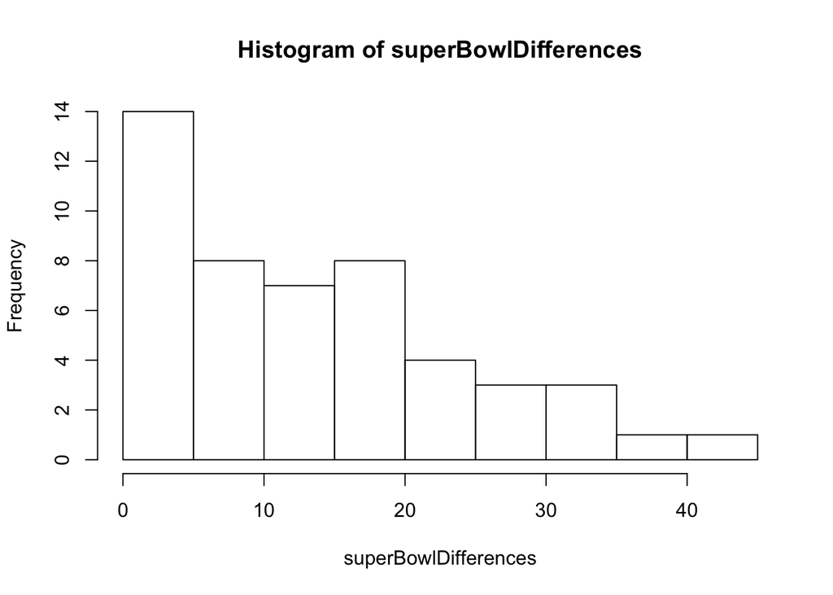

```r
hist(superBowlDifferences)
```

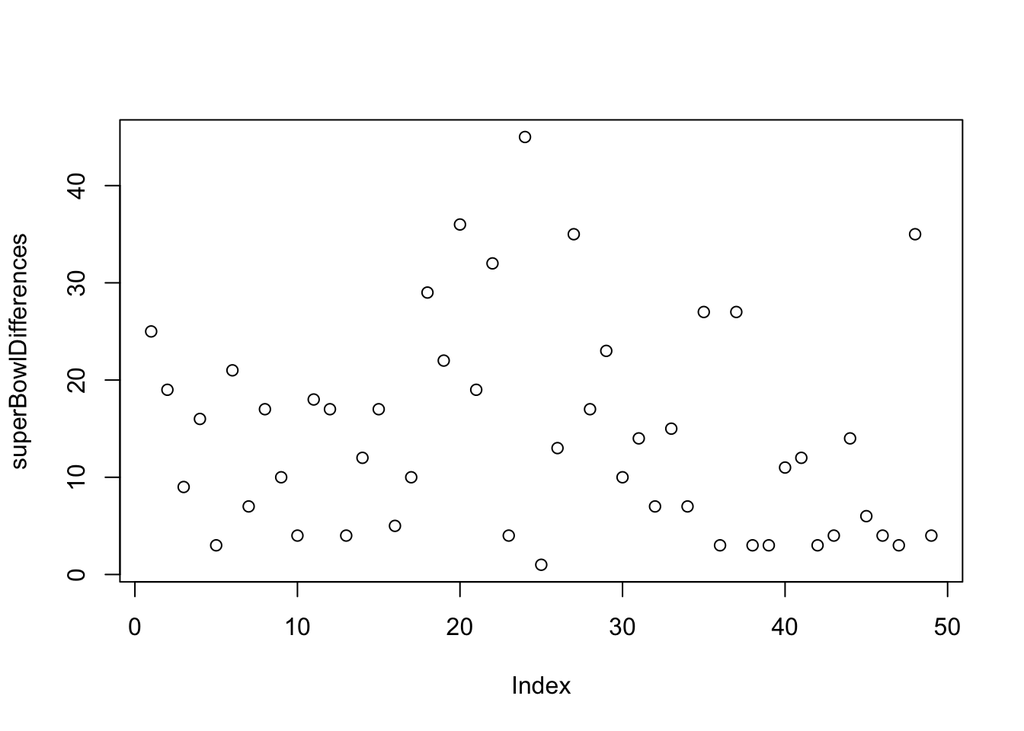

```r
plot(superBowlDifferences)
```

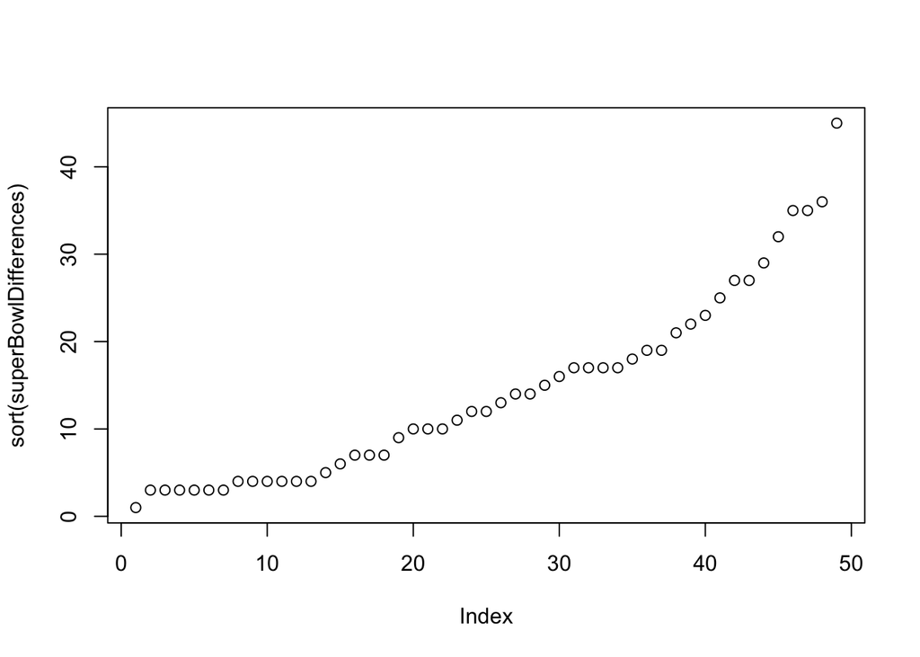

```r
plot(sort(superBowlDifferences))
```